# function: get_dupes()

Marisa Mackie

2023-04-11

## Function: get_dupes()

#### Introduction:

One issue that we sometimes run into when working with data is the presence of duplicate pieces of data, or “dupes”. This means that the **same information** is represented **more than once** in the same dataset.

Below is an example of data, with duplicates highlighted in red.

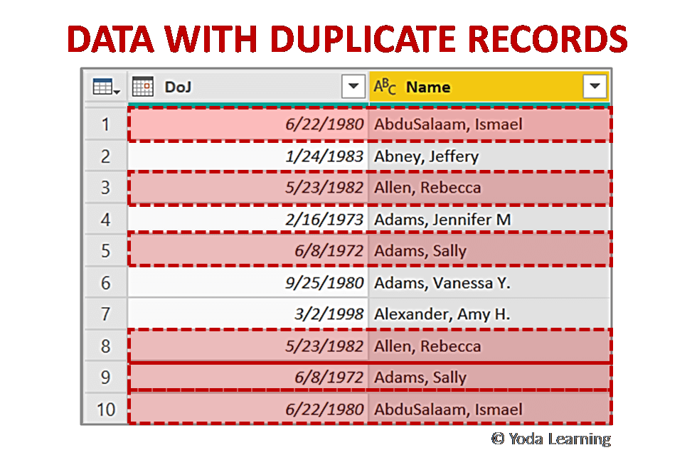

example of duplicate data

#### How do dupes happen?

A few ways that duplicates can happen are via human error:

- **User inputs data that is already there, i.e. they accidentally copy & pasted it twice**

| Name | Number |
| --- | --- |
| CSUN | 1 |
| CSUN | 1 |

- **The user inputs the *same* information in a *different way***

| Name | Number |
| --- | --- |
| CSUN | 1 |
| CSU Northridge | 1 |
| Cal State University Northridge | 1 |

- **Often these might be case sensitive**

| Name | Number |
| --- | --- |
| csun | 1 |
| Csun | 1 |
| CSUN | 1 |

- **Typos**

| Name | Number |
| --- | --- |
| CSU Northridge | 1 |
| CSU Notrhridge | 1 |

| ID | Number |
| --- | --- |
| 12200345000 | 1 |
| 12200354000 | 1 |

#### What can I do about dupes?

The first step in dealing with dupes is to identify them.

The **Janitor** package has a useful function called *get_dupes()* that identifies & returns duplicates for you.

To demonstrate this, let’s load in the *fruits_with_dupes* data.

```r
# load data
fruits <- read_csv(here("Marisa","Data","fruits_with_dupes.csv"))

# look at first 10 lines
head(fruits,10)
```

```
## # A tibble: 10 × 4
##    fruit      inside_color size_cm rating
##    <chr>      <chr>          <dbl>  <dbl>
##  1 apple      light yellow     7.8   8.75
##  2 orange     orange           7.7   8.5
##  3 pineapple  yellow          30     7.75
##  4 lime       green            5     9.5
##  5 lemon      yellow           8.5   8.5
##  6 strawberry red              2.5   9.25
##  7 mango      orange           9     9
##  8 peaches    orange           7.5   8.5
##  9 coconut    white           22     7.25
## 10 cranberry  red              2     7
```

Now let’s ask Janitor to get duplicates for us!

You can input the data within the arguments of the function, or pipe to the function from the data.

```r
# Returns exact duplicates from your data
get_dupes(fruits)
```

```
## No variable names specified - using all columns.
```

```
## # A tibble: 15 × 5
##    fruit      inside_color size_cm rating dupe_count
##    <chr>      <chr>          <dbl>  <dbl>      <int>
##  1 strawberry red              2.5   9.25          3
##  2 strawberry red              2.5   9.25          3
##  3 strawberry red              2.5   9.25          3
##  4 apple      light yellow     7.8   8.75          2
##  5 apple      light yellow     7.8   8.75          2
##  6 coconut    white           22     7.25          2
##  7 coconut    white           22     7.25          2
##  8 guava      pink             6.2   7             2
##  9 guava      pink             6.2   7             2
## 10 lime       green            5     9.5           2
## 11 lime       green            5     9.5           2
## 12 mango      orange           9     9             2
## 13 mango      orange           9     9             2
## 14 orange     orange           7.7   8.5           2
## 15 orange     orange           7.7   8.5           2
```

You can also specify which columns you are looking for in the data, for example, fruit and rating.

```r
# Returns exact duplicates from your data
fruits %>% get_dupes(fruit, rating)
```

```
## # A tibble: 15 × 5
##    fruit      rating dupe_count inside_color size_cm
##    <chr>       <dbl>      <int> <chr>          <dbl>
##  1 strawberry   9.25          3 red              2.5
##  2 strawberry   9.25          3 red              2.5
##  3 strawberry   9.25          3 red              2.5
##  4 apple        8.75          2 light yellow     7.8
##  5 apple        8.75          2 light yellow     7.8
##  6 coconut      7.25          2 white           22
##  7 coconut      7.25          2 white           22
##  8 guava        7             2 pink             6.2
##  9 guava        7             2 pink             6.2
## 10 lime         9.5           2 green            5
## 11 lime         9.5           2 green            5
## 12 mango        9             2 orange           9
## 13 mango        9             2 orange           9
## 14 orange       8.5           2 orange           7.7
## 15 orange       8.5           2 orange           7.7
```

As you can see, Janitor returns all the duplicate values for us, and even includes a new column **dupe_count** to tell us *how many* duplicate rows there are for each piece of data.

However, *get_dupes()* alone will only return **exact** duplicates of data. Misspellings or differences in user input wouldn’t show up.

I have gone ahead and extracted the rows that contain *non-exact* duplicates below so we can see them.

```
## # A tibble: 8 × 4
##   fruit       inside_color size_cm rating
##   <chr>       <chr>          <dbl>  <dbl>
## 1 peaches     orange           7.5    8.5
## 2 peach       orange           7.5    8.5
## 3 banana      yellow          13      8.5
## 4 cherry      red              2      8
## 5 bananas     yellow          13      8.5
## 6 pomegranate red              7.6    9.5
## 7 pomegranite red              7.6    9.5
## 8 cherries    red              2      8
```

As you can see we have a few examples of non-exact duplicates here:

- Misspellings - *“pomegranate”* vs *“pomegranite”*
- Variations (plural & singular) - *“banana”* vs *“bananas”*

Since *get_dupes* returns only *exact duplicates*, we wouldn’t be able to return non-exact duplicates without the help of other functions and/or packages.

#### For advanced duplicate searches:

For a small & manageable list where we are familiar with all the data entries (like the fruits data), we may be able to find most of the duplicates using extra functions that can filter for similarly-spelled words.

However, if we had a very large data set with data entries that we were mostly unfamiliar with, we would have no way of knowing if we managed to find every single possible misspelling/variation of a word, and it would be very difficult to find these types of duplicates without some techniques that are far more advanced than our current level of coding, and beyond the scope of this class.